# vehicle sillhoute (5) (2) (2) - Jupyter Notebook

```
xxxxxxxxxx
```

```
<h1><pre>                   Vehicle Silhouettes</pre></h1>
```

```
<h2>Goal of collecting this dataset:</h2>
```

```
The goal of collecting this dataset is to determine the category of a given vehicle silhouette among three types (car, van, bus) by utilizing a set of extracted silhouette-based features.
```

```
<h2>Classification:</h2>
```

```
The classification of vehicle silhouettes involves the utilization of a set of distinctive attributes extracted from these silhouettes. The primary objective is to categorize these silhouettes into one of three predefined classes: cars, vans, or buses.
```

```
<h2>Clustering:</h2>
```

```
Clustering vehicle silhouettes entails organizing similar data based on their shared characteristics to create distinct clusters. Various methods will be utilized to determine the number of clusters that best suit our dataset, followed by evaluation techniques to assess the effectiveness of these clusters in segmenting the data effectively based on their inherent features.
```

```
<h2>Defect prediction:</h2>
```

```
Defect prediction in a dataset of vehicle silhouettes involves spotting potential issues or irregularities within these silhouette images. This process may encompass the detection of inconsistencies or abnormalities in the silhouettes, including the presence of missing data points, which can be problematic. Leveraging data mining techniques, defect prediction enhances the dataset's overall quality and dependability, ensuring it faithfully reflects the desired information. This, in turn, reduces the risk of producing inaccurate or deceptive outcomes when the dataset is applied in subsequent tasks and applications, such as object recognition and classification.
```

```
<h4>Link Of dataset:</h4>
```

```
<a href=https://www.kaggle.com/datasets/pritech/vehicle-silhouettes/data>link of dataset</a>
```

```
Number of attribute:
```

```
19
```

```
Number of objects:
```

[output not shown]

# Vehicle Silhouettes

## Goal of collecting this dataset:

The goal of collecting this dataset is to determine the category of a given vehicle silhouette among three types (car, van, bus) by utilizing a set of extracted silhouette-based features.

## Classification:

The classification of vehicle silhouettes involves the utilization of a set of distinctive attributes extracted from these silhouettes. The primary objective is to categorize these silhouettes into one of three predefined classes: cars, vans, or buses.

## Clustering:

Clustering vehicle silhouettes entails organizing similar data based on their shared characteristics to create distinct clusters. Various methods will be utilized to determine the number of clusters that best suit our dataset, followed by evaluation techniques to assess the effectiveness of these clusters in segmenting the data effectively based on their inherent features.

## Defect prediction:

Defect prediction in a dataset of vehicle silhouettes involves spotting potential issues or irregularities within these silhouette images. This process may encompass the detection of inconsistencies or abnormalities in the silhouettes, including the presence of missing data points, which can be problematic. Leveraging data mining techniques, defect prediction enhances the dataset's overall quality and dependability, ensuring it faithfully reflects the desired information. This, in turn, reduces the risk of producing inaccurate or deceptive outcomes when the dataset is applied in subsequent tasks and applications, such as object recognition and classification.

#### Link Of dataset:

[link of dataset](https://www.kaggle.com/datasets/pritech/vehicle-silhouettes/data)

```
xxxxxxxxxx
```

```
setwd("C:/Users/Tshah/OneDrive/Desktop/326/our notebook/vehicle.csv")
```

[output not shown]

```
xxxxxxxxxx
```

```
dataset<-read.csv('vehicle.csv')
```

```
databeforereprossess<-read.csv('vehicle.csv')
```

```
xxxxxxxxxx
```

```
<h3> Let us dive into our dataset to undertsand it more::</h3>
```

```
<h1>A.Before preprocessing, Understanding the dataset</h1>
```

### Let us dive into our dataset to undertsand it more::

# A.Before preprocessing, Understanding the dataset

```
xxxxxxxxxx
```

```
head(dataset)
```

| compactness | circularity | distance_circularity | radius_ratio | pr.axis_aspect_ratio | max.length_aspect_ratio | scatter_ratio | elongatedness | pr.axis_rectangularity | max.length_rectangularity | scaled_variance | scaled_variance.1 | scaled_radius_of_gyration | scaled_radius_of_gyration.1 | skewness_about | skewness_about.1 | skewness_about.2 | hollows_ratio | class |
| --- | --- | --- | --- | --- | --- | --- | --- | --- | --- | --- | --- | --- | --- | --- | --- | --- | --- | --- |
| 95 | 48 | 83 | 178 | 72 | 10 | 162 | 42 | 20 | 159 | 176 | 379 | 184 | 70 | 6 | 16 | 187 | 197 | van |
| 91 | 41 | 84 | 141 | 57 | 9 | 149 | 45 | 19 | 143 | 170 | 330 | 158 | 72 | 9 | 14 | 189 | 199 | van |
| 104 | 50 | 106 | 209 | 66 | 10 | 207 | 32 | 23 | 158 | 223 | 635 | 220 | 73 | 14 | 9 | 188 | 196 | car |
| 93 | 41 | 82 | 159 | 63 | 9 | 144 | 46 | 19 | 143 | 160 | 309 | 127 | 63 | 6 | 10 | 199 | 207 | van |
| 85 | 44 | 70 | 205 | 103 | 52 | 149 | 45 | 19 | 144 | 241 | 325 | 188 | 127 | 9 | 11 | 180 | 183 | bus |
| 107 | NA | 106 | 172 | 50 | 6 | 255 | 26 | 28 | 169 | 280 | 957 | 264 | 85 | 5 | 9 | 181 | 183 | bus |

```
xxxxxxxxxx
```

```
<p>Reviewing a section of our dataset, it's evident that there are missing values, significant ranges in certain data, and our dataset comprises numeric values to predict our categorical class label.</p>
```

Reviewing a section of our dataset, it's evident that there are missing values, significant ranges in certain data, and our dataset comprises numeric values to predict our categorical class label.

```
xxxxxxxxxx
```

```
str(dataset)
```

```
'data.frame':	846 obs. of  19 variables:
 $ compactness                : int  95 91 104 93 85 107 97 90 86 93 ...
 $ circularity                : int  48 41 50 41 44 NA 43 43 34 44 ...
 $ distance_circularity       : int  83 84 106 82 70 106 73 66 62 98 ...
 $ radius_ratio               : int  178 141 209 159 205 172 173 157 140 NA ...
 $ pr.axis_aspect_ratio       : int  72 57 66 63 103 50 65 65 61 62 ...
 $ max.length_aspect_ratio    : int  10 9 10 9 52 6 6 9 7 11 ...
 $ scatter_ratio              : int  162 149 207 144 149 255 153 137 122 183 ...
 $ elongatedness              : int  42 45 32 46 45 26 42 48 54 36 ...
 $ pr.axis_rectangularity     : int  20 19 23 19 19 28 19 18 17 22 ...
 $ max.length_rectangularity  : int  159 143 158 143 144 169 143 146 127 146 ...
 $ scaled_variance            : int  176 170 223 160 241 280 176 162 141 202 ...
 $ scaled_variance.1          : int  379 330 635 309 325 957 361 281 223 505 ...
 $ scaled_radius_of_gyration  : int  184 158 220 127 188 264 172 164 112 152 ...
 $ scaled_radius_of_gyration.1: int  70 72 73 63 127 85 66 67 64 64 ...
 $ skewness_about             : int  6 9 14 6 9 5 13 3 2 4 ...
 $ skewness_about.1           : int  16 14 9 10 11 9 1 3 14 14 ...
 $ skewness_about.2           : int  187 189 188 199 180 181 200 193 200 195 ...
 $ hollows_ratio              : int  197 199 196 207 183 183 204 202 208 204 ...
 $ class                      : Factor w/ 3 levels "bus","car","van": 3 3 2 3 1 1 1 3 3 2 ...
```

```
xxxxxxxxxx
```

```
<p>As we can see our dataset consists of 18 integer columns primarily designed for  classification purposes, aiding in the distinction of various vehicle types such as cars, vans, and buses. These 18 integer-based metrics provide a detailed perspective on diverse vehicle attributes, enabling precise and reliable classification.</p>
```

As we can see our dataset consists of 18 integer columns primarily designed for classification purposes, aiding in the distinction of various vehicle types such as cars, vans, and buses. These 18 integer-based metrics provide a detailed perspective on diverse vehicle attributes, enabling precise and reliable classification.

```
xxxxxxxxxx
```

```
<h6> The following information is about number of rows and columns:</h6>
```

###### The following information is about number of rows and columns:

```
xxxxxxxxxx
```

```
##The number of rows:
```

```
nrow(dataset)
```

846

```
xxxxxxxxxx
```

```
##The number of columns:
```

```
ncol(dataset)
```

19

```
xxxxxxxxxx
```

```
##Lets check summary of our attributes
```

```
summary(dataset)
```

```
  compactness      circularity    distance_circularity  radius_ratio
 Min.   : 73.00   Min.   :33.00   Min.   : 40.00       Min.   :104.0
 1st Qu.: 87.00   1st Qu.:40.00   1st Qu.: 70.00       1st Qu.:141.0
 Median : 93.00   Median :44.00   Median : 80.00       Median :167.0
 Mean   : 93.68   Mean   :44.83   Mean   : 82.11       Mean   :168.9
 3rd Qu.:100.00   3rd Qu.:49.00   3rd Qu.: 98.00       3rd Qu.:195.0
 Max.   :119.00   Max.   :59.00   Max.   :112.00       Max.   :333.0
                  NA's   :5       NA's   :4            NA's   :6
 pr.axis_aspect_ratio max.length_aspect_ratio scatter_ratio   elongatedness
 Min.   : 47.00       Min.   : 2.000          Min.   :112.0   Min.   :26.00
 1st Qu.: 57.00       1st Qu.: 7.000          1st Qu.:147.0   1st Qu.:33.00
 Median : 61.00       Median : 8.000          Median :157.0   Median :43.00
 Mean   : 61.68       Mean   : 8.567          Mean   :168.9   Mean   :40.93
 3rd Qu.: 65.00       3rd Qu.:10.000          3rd Qu.:198.0   3rd Qu.:46.00
 Max.   :138.00       Max.   :55.000          Max.   :265.0   Max.   :61.00
 NA's   :2                                    NA's   :1       NA's   :1
 pr.axis_rectangularity max.length_rectangularity scaled_variance
 Min.   :17.00          Min.   :118               Min.   :130.0
 1st Qu.:19.00          1st Qu.:137               1st Qu.:167.0
 Median :20.00          Median :146               Median :179.0
 Mean   :20.58          Mean   :148               Mean   :188.6
 3rd Qu.:23.00          3rd Qu.:159               3rd Qu.:217.0
 Max.   :29.00          Max.   :188               Max.   :320.0
 NA's   :3                                        NA's   :3
 scaled_variance.1 scaled_radius_of_gyration scaled_radius_of_gyration.1
 Min.   : 184.0    Min.   :109.0             Min.   : 59.00
 1st Qu.: 318.0    1st Qu.:149.0             1st Qu.: 67.00
 Median : 363.5    Median :173.5             Median : 71.50
 Mean   : 439.5    Mean   :174.7             Mean   : 72.45
 3rd Qu.: 587.0    3rd Qu.:198.0             3rd Qu.: 75.00
 Max.   :1018.0    Max.   :268.0             Max.   :135.00
 NA's   :2         NA's   :2                 NA's   :4
 skewness_about   skewness_about.1 skewness_about.2 hollows_ratio   class
 Min.   : 0.000   Min.   : 0.0     Min.   :176.0    Min.   :181.0   bus:218
 1st Qu.: 2.000   1st Qu.: 5.0     1st Qu.:184.0    1st Qu.:190.2   car:429
 Median : 6.000   Median :11.0     Median :188.0    Median :197.0   van:199
 Mean   : 6.364   Mean   :12.6     Mean   :188.9    Mean   :195.6
 3rd Qu.: 9.000   3rd Qu.:19.0     3rd Qu.:193.0    3rd Qu.:201.0
 Max.   :22.000   Max.   :41.0     Max.   :206.0    Max.   :211.0
 NA's   :6        NA's   :1        NA's   :1
```

```
xxxxxxxxxx
```

```
<p>The dataset includes 846 records and 19 attributes, aiming to classify
```

```
vehicle silhouettes as 'bus', 'car', or 'van'. These attributes,
```

```
numerically expressed, capture distinct silhouette features of the
```

```
vehicles. An analysis of the data shows that certain attributes such as
```

```
'scaled_variance.1', 'scaled_radius_of_gyration', and
```

```
'scaled_radius_of_gyration.1' exhibit a broader range and relatively
```

```
higher maximum values compared to other features. Moreover,
```

```
'pr.axis_rectangularity' and 'max.length_rectangularity' seem to have a
```

```
connection with the vehicle's compactness. There are isolated outliers
```

```
present in specific attributes that could potentially impact the
```

```
analysis.
```

```
The categorical variable 'class' enumerates vehicle classifications,
```

```
noting counts of observations for 'bus' (218), 'car' (429), and 'van'
```

```
(199). The notably high count of 'car' compared to the other categories
```

```
indicates a dataset imbalance. This dataset holds promise for predictive
```

```
modeling to categorize vehicles based on their silhouette attributes.
```

```
However, it requires cleaning and preprocessing before model development
```

```
to ensure more accurate and dependable predictions.</p>
```

The dataset includes 846 records and 19 attributes, aiming to classify vehicle silhouettes as 'bus', 'car', or 'van'. These attributes, numerically expressed, capture distinct silhouette features of the vehicles. An analysis of the data shows that certain attributes such as 'scaled_variance.1', 'scaled_radius_of_gyration', and 'scaled_radius_of_gyration.1' exhibit a broader range and relatively higher maximum values compared to other features. Moreover, 'pr.axis_rectangularity' and 'max.length_rectangularity' seem to have a connection with the vehicle's compactness. There are isolated outliers present in specific attributes that could potentially impact the analysis.

The categorical variable 'class' enumerates vehicle classifications, noting counts of observations for 'bus' (218), 'car' (429), and 'van' (199). The notably high count of 'car' compared to the other categories indicates a dataset imbalance. This dataset holds promise for predictive modeling to categorize vehicles based on their silhouette attributes. However, it requires cleaning and preprocessing before model development to ensure more accurate and dependable predictions.

```
xxxxxxxxxx
```

[output not shown]

```
xxxxxxxxxx
```

```
sum(duplicated(dataset))
```

0

```
xxxxxxxxxx
```

```
The result of '0' signifies that within the dataset, there are no rows
```

```
that are exact replicas of one another. Essentially, each row in the
```

```
dataset is distinct, ensuring that there are no identical rows present.
```

The result of '0' signifies that within the dataset, there are no rows that are exact replicas of one another. Essentially, each row in the dataset is distinct, ensuring that there are no identical rows present.

```
xxxxxxxxxx
```

```
<h4>Lets check for missing values:</h4>
```

#### Lets check for missing values:

```
xxxxxxxxxx
```

```
##checking null values
```

```
is.na(dataset)
```

[output not shown]

```
xxxxxxxxxx
```

```
##checking for null values
```

```
sum(is.na(dataset))
```

41

```
xxxxxxxxxx
```

```
attributes(dataset)
```

```
##where class is our class label
```

**$names**

1. 'compactness'

2. 'circularity'

3. 'distance_circularity'

4. 'radius_ratio'

5. 'pr.axis_aspect_ratio'

6. 'max.length_aspect_ratio'

7. 'scatter_ratio'

8. 'elongatedness'

9. 'pr.axis_rectangularity'

10. 'max.length_rectangularity'

11. 'scaled_variance'

12. 'scaled_variance.1'

13. 'scaled_radius_of_gyration'

14. 'scaled_radius_of_gyration.1'

15. 'skewness_about'

16. 'skewness_about.1'

17. 'skewness_about.2'

18. 'hollows_ratio'

19. 'class'

**$class**

'data.frame'

1. 1

2. 2

3. 3

4. 4

5. 5

6. 6

7. 7

8. 8

9. 9

10. 10

11. 11

12. 12

13. 13

14. 14

15. 15

16. 16

17. 17

18. 18

19. 19

20. 20

21. 21

22. 22

23. 23

24. 24

25. 25

26. 26

27. 27

28. 28

29. 29

30. 30

31. 31

32. 32

33. 33

34. 34

35. 35

36. 36

37. 37

38. 38

39. 39

40. 40

41. 41

42. 42

43. 43

44. 44

45. 45

46. 46

47. 47

48. 48

49. 49

50. 50

51. 51

52. 52

53. 53

54. 54

55. 55

56. 56

57. 57

58. 58

59. 59

60. 60

61. 61

62. 62

63. 63

64. 64

65. 65

66. 66

67. 67

68. 68

69. 69

70. 70

71. 71

72. 72

73. 73

74. 74

75. 75

76. 76

77. 77

78. 78

79. 79

80. 80

81. 81

82. 82

83. 83

84. 84

85. 85

86. 86

87. 87

88. 88

89. 89

90. 90

91. 91

92. 92

93. 93

94. 94

95. 95

96. 96

97. 97

98. 98

99. 99

100. 100

101. 101

102. 102

103. 103

104. 104

105. 105

106. 106

107. 107

108. 108

109. 109

110. 110

111. 111

112. 112

113. 113

114. 114

115. 115

116. 116

117. 117

118. 118

119. 119

120. 120

121. 121

122. 122

123. 123

124. 124

125. 125

126. 126

127. 127

128. 128

129. 129

130. 130

131. 131

132. 132

133. 133

134. 134

135. 135

136. 136

137. 137

138. 138

139. 139

140. 140

141. 141

142. 142

143. 143

144. 144

145. 145

146. 146

147. 147

148. 148

149. 149

150. 150

151. 151

152. 152

153. 153

154. 154

155. 155

156. 156

157. 157

158. 158

159. 159

160. 160

161. 161

162. 162

163. 163

164. 164

165. 165

166. 166

167. 167

168. 168

169. 169

170. 170

171. 171

172. 172

173. 173

174. 174

175. 175

176. 176

177. 177

178. 178

179. 179

180. 180

181. 181

182. 182

183. 183

184. 184

185. 185

186. 186

187. 187

188. 188

189. 189

190. 190

191. 191

192. 192

193. 193

194. 194

195. 195

196. 196

197. 197

198. 198

199. 199

200. 200

201. 201

202. 202

203. 203

204. 204

205. 205

206. 206

207. 207

208. 208

209. 209

210. 210

211. 211

212. 212

213. 213

214. 214

215. 215

216. 216

217. 217

218. 218

219. 219

220. 220

221. 221

222. 222

223. 223

224. 224

225. 225

226. 226

227. 227

228. 228

229. 229

230. 230

231. 231

232. 232

233. 233

234. 234

235. 235

236. 236

237. 237

238. 238

239. 239

240. 240

241. 241

242. 242

243. 243

244. 244

245. 245

246. 246

247. 247

248. 248

249. 249

250. 250

251. 251

252. 252

253. 253

254. 254

255. 255

256. 256

257. 257

258. 258

259. 259

260. 260

261. 261

262. 262

263. 263

264. 264

265. 265

266. 266

267. 267

268. 268

269. 269

270. 270

271. 271

272. 272

273. 273

274. 274

275. 275

276. 276

277. 277

278. 278

279. 279

280. 280

281. 281

282. 282

283. 283

284. 284

285. 285

286. 286

287. 287

288. 288

289. 289

290. 290

291. 291

292. 292

293. 293

294. 294

295. 295

296. 296

297. 297

298. 298

299. 299

300. 300

301. 301

302. 302

303. 303

304. 304

305. 305

306. 306

307. 307

308. 308

309. 309

310. 310

311. 311

312. 312

313. 313

314. 314

315. 315

316. 316

317. 317

318. 318

319. 319

320. 320

321. 321

322. 322

323. 323

324. 324

325. 325

326. 326

327. 327

328. 328

329. 329

330. 330

331. 331

332. 332

333. 333

334. 334

335. 335

336. 336

337. 337

338. 338

339. 339

340. 340

341. 341

342. 342

343. 343

344. 344

345. 345

346. 346

347. 347

348. 348

349. 349

350. 350

351. 351

352. 352

353. 353

354. 354

355. 355

356. 356

357. 357

358. 358

359. 359

360. 360

361. 361

362. 362

363. 363

364. 364

365. 365

366. 366

367. 367

368. 368

369. 369

370. 370

371. 371

372. 372

373. 373

374. 374

375. 375

376. 376

377. 377

378. 378

379. 379

380. 380

381. 381

382. 382

383. 383

384. 384

385. 385

386. 386

387. 387

388. 388

389. 389

390. 390

391. 391

392. 392

393. 393

394. 394

395. 395

396. 396

397. 397

398. 398

399. 399

400. 400

401. 401

402. 402

403. 403

404. 404

405. 405

406. 406

407. 407

408. 408

409. 409

410. 410

411. 411

412. 412

413. 413

414. 414

415. 415

416. 416

417. 417

418. 418

419. 419

420. 420

421. 421

422. 422

423. 423

424. 424

425. 425

426. 426

427. 427

428. 428

429. 429

430. 430

431. 431

432. 432

433. 433

434. 434

435. 435

436. 436

437. 437

438. 438

439. 439

440. 440

441. 441

442. 442

443. 443

444. 444

445. 445

446. 446

447. 447

448. 448

449. 449

450. 450

451. 451

452. 452

453. 453

454. 454

455. 455

456. 456

457. 457

458. 458

459. 459

460. 460

461. 461

462. 462

463. 463

464. 464

465. 465

466. 466

467. 467

468. 468

469. 469

470. 470

471. 471

472. 472

473. 473

474. 474

475. 475

476. 476

477. 477

478. 478

479. 479

480. 480

481. 481

482. 482

483. 483

484. 484

485. 485

486. 486

487. 487

488. 488

489. 489

490. 490

491. 491

492. 492

493. 493

494. 494

495. 495

496. 496

497. 497

498. 498

499. 499

500. 500

501. 501

502. 502

503. 503

504. 504

505. 505

506. 506

507. 507

508. 508

509. 509

510. 510

511. 511

512. 512

513. 513

514. 514

515. 515

516. 516

517. 517

518. 518

519. 519

520. 520

521. 521

522. 522

523. 523

524. 524

525. 525

526. 526

527. 527

528. 528

529. 529

530. 530

531. 531

532. 532

533. 533

534. 534

535. 535

536. 536

537. 537

538. 538

539. 539

540. 540

541. 541

542. 542

543. 543

544. 544

545. 545

546. 546

547. 547

548. 548

549. 549

550. 550

551. 551

552. 552

553. 553

554. 554

555. 555

556. 556

557. 557

558. 558

559. 559

560. 560

561. 561

562. 562

563. 563

564. 564

565. 565

566. 566

567. 567

568. 568

569. 569

570. 570

571. 571

572. 572

573. 573

574. 574

575. 575

576. 576

577. 577

578. 578

579. 579

580. 580

581. 581

582. 582

583. 583

584. 584

585. 585

586. 586

587. 587

588. 588

589. 589

590. 590

591. 591

592. 592

593. 593

594. 594

595. 595

596. 596

597. 597

598. 598

599. 599

600. 600

601. 601

602. 602

603. 603

604. 604

605. 605

606. 606

607. 607

608. 608

609. 609

610. 610

611. 611

612. 612

613. 613

614. 614

615. 615

616. 616

617. 617

618. 618

619. 619

620. 620

621. 621

622. 622

623. 623

624. 624

625. 625

626. 626

627. 627

628. 628

629. 629

630. 630

631. 631

632. 632

633. 633

634. 634

635. 635

636. 636

637. 637

638. 638

639. 639

640. 640

641. 641

642. 642

643. 643

644. 644

645. 645

646. 646

647. 647

648. 648

649. 649

650. 650

651. 651

652. 652

653. 653

654. 654

655. 655

656. 656

657. 657

658. 658

659. 659

660. 660

661. 661

662. 662

663. 663

664. 664

665. 665

666. 666

667. 667

668. 668

669. 669

670. 670

671. 671

672. 672

673. 673

674. 674

675. 675

676. 676

677. 677

678. 678

679. 679

680. 680

681. 681

682. 682

683. 683

684. 684

685. 685

686. 686

687. 687

688. 688

689. 689

690. 690

691. 691

692. 692

693. 693

694. 694

695. 695

696. 696

697. 697

698. 698

699. 699

700. 700

701. 701

702. 702

703. 703

704. 704

705. 705

706. 706

707. 707

708. 708

709. 709

710. 710

711. 711

712. 712

713. 713

714. 714

715. 715

716. 716

717. 717

718. 718

719. 719

720. 720

721. 721

722. 722

723. 723

724. 724

725. 725

726. 726

727. 727

728. 728

729. 729

730. 730

731. 731

732. 732

733. 733

734. 734

735. 735

736. 736

737. 737

738. 738

739. 739

740. 740

741. 741

742. 742

743. 743

744. 744

745. 745

746. 746

747. 747

748. 748

749. 749

750. 750

751. 751

752. 752

753. 753

754. 754

755. 755

756. 756

757. 757

758. 758

759. 759

760. 760

761. 761

762. 762

763. 763

764. 764

765. 765

766. 766

767. 767

768. 768

769. 769

770. 770

771. 771

772. 772

773. 773

774. 774

775. 775

776. 776

777. 777

778. 778

779. 779

780. 780

781. 781

782. 782

783. 783

784. 784

785. 785

786. 786

787. 787

788. 788

789. 789

790. 790

791. 791

792. 792

793. 793

794. 794

795. 795

796. 796

797. 797

798. 798

799. 799

800. 800

801. 801

802. 802

803. 803

804. 804

805. 805

806. 806

807. 807

808. 808

809. 809

810. 810

811. 811

812. 812

813. 813

814. 814

815. 815

816. 816

817. 817

818. 818

819. 819

820. 820

821. 821

822. 822

823. 823

824. 824

825. 825

826. 826

827. 827

828. 828

829. 829

830. 830

831. 831

832. 832

833. 833

834. 834

835. 835

836. 836

837. 837

838. 838

839. 839

840. 840

841. 841

842. 842

843. 843

844. 844

845. 845

846. 846

```
xxxxxxxxxx
```

```
The data contains 19 variables including 'compactness', 'circularity',
```

```
'distance_circularity', 'radius_ratio', 'pr.axis_aspect_ratio',
```

```
'max.length_aspect_ratio', 'scatter_ratio', 'elongatedness',
```

```
'pr.axis_rectangularity', 'max.length_rectangularity',
```

```
'scaled_variance', 'scaled_variance.1', 'scaled_radius_of_gyration',
```

```
'scaled_radius_of_gyration.1', 'skewness_about', 'skewness_about.1',
```

```
'skewness_about.2', 'hollows_ratio', and 'class'. The 'class' variable
```

```
appears to be categorical with 846 observations, as indicated by the
```

```
range of row numbers from 1 to 846. This suggests the dataset is
```

```
structured and comprehensive.
```

The data contains 19 variables including 'compactness', 'circularity', 'distance_circularity', 'radius_ratio', 'pr.axis_aspect_ratio', 'max.length_aspect_ratio', 'scatter_ratio', 'elongatedness', 'pr.axis_rectangularity', 'max.length_rectangularity', 'scaled_variance', 'scaled_variance.1', 'scaled_radius_of_gyration', 'scaled_radius_of_gyration.1', 'skewness_about', 'skewness_about.1', 'skewness_about.2', 'hollows_ratio', and 'class'. The 'class' variable appears to be categorical with 846 observations, as indicated by the range of row numbers from 1 to 846. This suggests the dataset is structured and comprehensive.

```
xxxxxxxxxx
```

```
# import necessary libraries
```

```
library(dplyr)
```

```
library(tidyr)
```

```
library(readr)
```

```
library(outliers)
```

```
xxxxxxxxxx
```

```
<h3>The following is graphs of some of our attribute to understand it more.</h3>
```

### The following is graphs of some of our attribute to understand it more.

```
xxxxxxxxxx
```

```
hist(dataset$max.length_aspect_ratio)
```

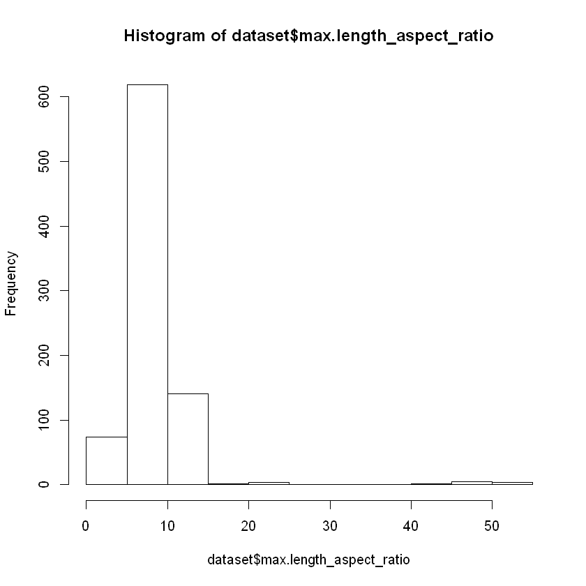

```
xxxxxxxxxx
```

```
<p>The histogram shows the freguency  of the max length aspect ratio which varies widely depending on the type and purpose of the vehicle which will help us in categorizing it.</p>
```

The histogram shows the freguency of the max length aspect ratio which varies widely depending on the type and purpose of the vehicle which will help us in categorizing it.

```
xxxxxxxxxx
```

```
with(dataset, plot(skewness_about, hollows_ratio, col = class, pch = as.numeric(class)))
```

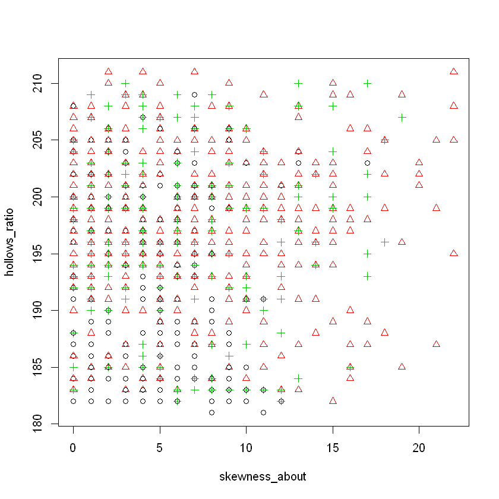

```
xxxxxxxxxx
```

```
<p>As we can see our class is spread out according to the columns we have chosen.</p>
```

As we can see our class is spread out according to the columns we have chosen.

```
xxxxxxxxxx
```

```
hear All the boxplots for the outliers
```

hear All the boxplots for the outliers

```
xxxxxxxxxx
```

```
![image.png](attachment:image.png)
```

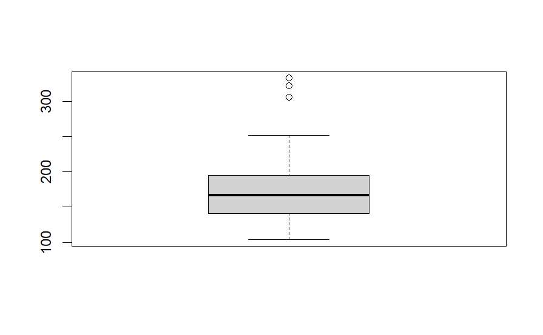

```
xxxxxxxxxx
```

```
radius_ratio founded outliers 3
```

radius_ratio founded outliers 3

```
xxxxxxxxxx
```

```
![image.png](attachment:image.png)
```

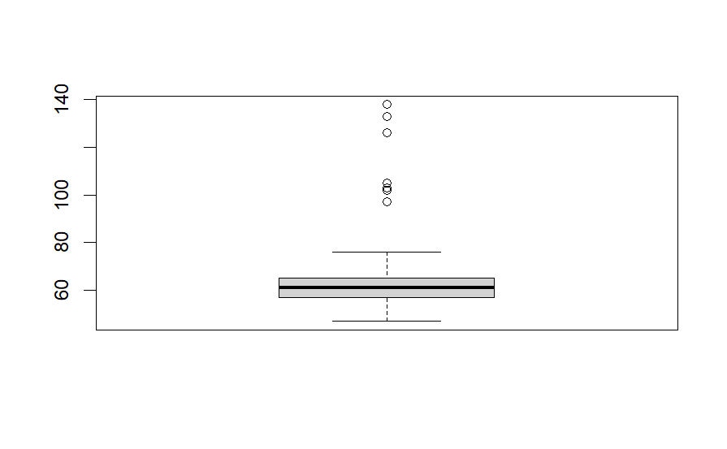

```
xxxxxxxxxx
```

```
pr.axis_aspect_ratio outliers 8
```

pr.axis_aspect_ratio outliers 8

```
xxxxxxxxxx
```

```
![image.png](attachment:image.png)
```

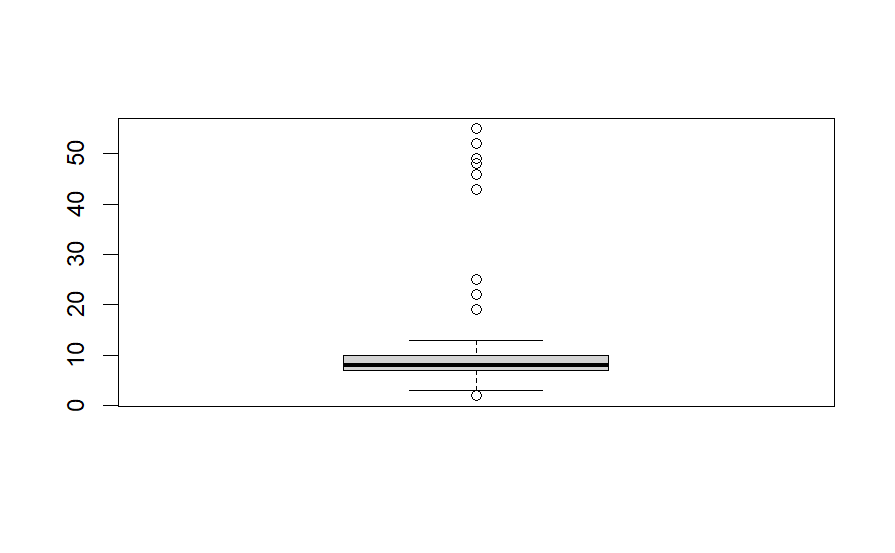

```
xxxxxxxxxx
```

[output not shown]

```
xxxxxxxxxx
```

```
![image.png](attachment:image.png)
```

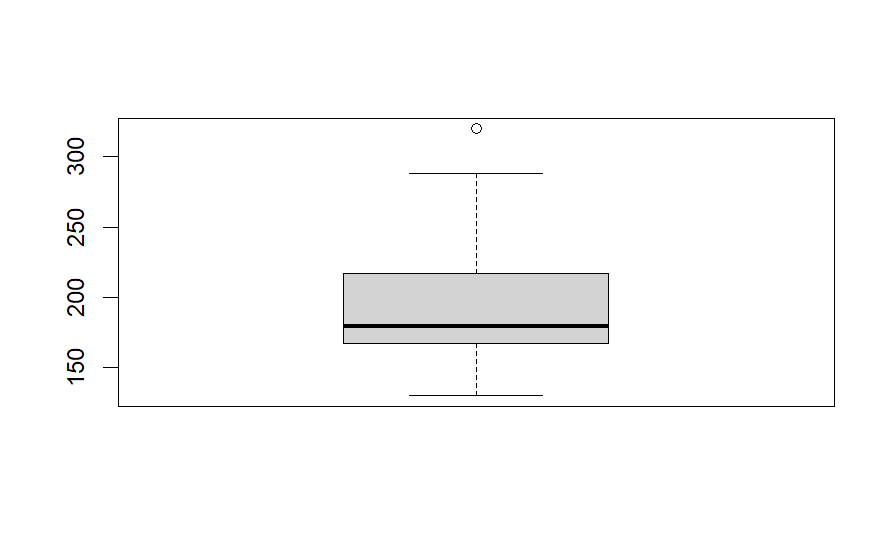

```
xxxxxxxxxx
```

```
scaled_variance outliers is 1
```

scaled_variance outliers is 1

```
xxxxxxxxxx
```

```
![image.png](attachment:image.png)
```

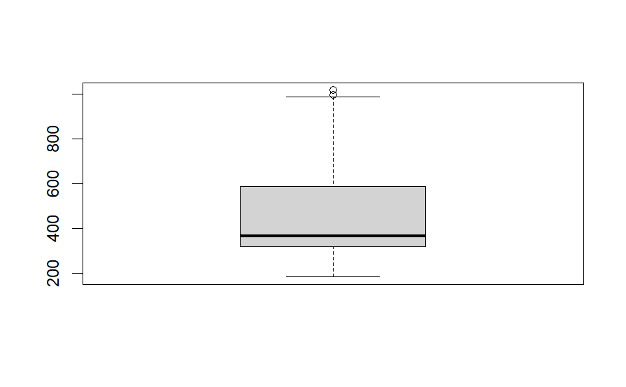

```
xxxxxxxxxx
```

```
scaled_variance.1 outliers is 2
```

scaled_variance.1 outliers is 2

```
xxxxxxxxxx
```

```
![image.png](attachment:image.png)
```

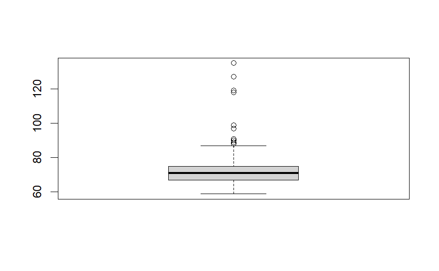

```
xxxxxxxxxx
```

```
scaled_radius_of_gyration.1 is outliers is 10
```

scaled_radius_of_gyration.1 is outliers is 10

```
xxxxxxxxxx
```

```
![image.png](attachment:image.png)
```

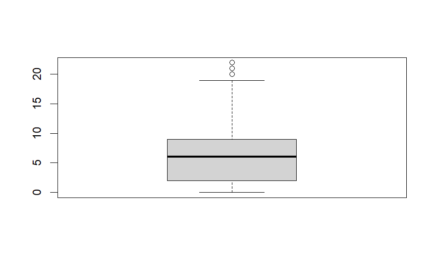

```
xxxxxxxxxx
```

```
skewness_about is outliers is 3
```

skewness_about is outliers is 3

```
xxxxxxxxxx
```

```
![image.png](attachment:image.png)
```

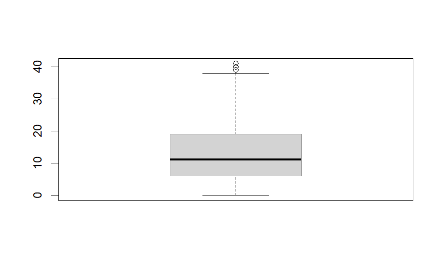

```
xxxxxxxxxx
```

```
skewness_about.1 is outliers is 3
```

skewness_about.1 is outliers is 3

```
xxxxxxxxxx
```

```
<p>
```

```
Based on the boxplot analysis, it is evident that several columns in our dataset exhibit outliers. We will take care of these outliers during preprocessing stage.</p>
```

Based on the boxplot analysis, it is evident that several columns in our dataset exhibit outliers. We will take care of these outliers during preprocessing stage.

```
xxxxxxxxxx
```

```
##lets look at some correlations and coveriance
```

```
cov(dataset$compactness, dataset$hollows_ratio)
```

```
cor(dataset$compactness, dataset$hollows_ratio)
```

```
cov(dataset$max.length_aspect_ratio, dataset$hollows_ratio)
```

```
cor(dataset$max.length_aspect_ratio, dataset$hollows_ratio)
```

22.3917271671772

0.365551849482487

4.92598094758488

0.143918727943028

```
xxxxxxxxxx
```

```
<p>The is a correlation between compactness and hollows_ratio but a weak one, which means that we cant delete any of them.<br>There is a correlation as well in max length and hollows ratio but its also a weak correlation<br>Both pairs have a high coveriance</p>
```

The is a correlation between compactness and hollows_ratio but a weak one, which means that we cant delete any of them.  
There is a correlation as well in max length and hollows ratio but its also a weak correlation  
Both pairs have a high coveriance

```
xxxxxxxxxx
```

```
<h4>Lets check if our data is balanced or not</h4>
```

#### Lets check if our data is balanced or not

```
xxxxxxxxxx
```

```
![before%20balance.png](attachment:before%20balance.png)
```

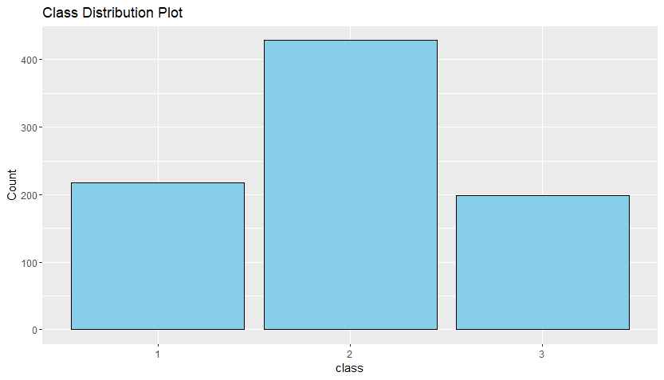

```
xxxxxxxxxx
```

```
After analyzing the dataset, we have observed that the distribution of
```

```
the 'class' variable is unbalanced, with some classes having
```

```
significantly fewer instances than others. To address this class
```

```
imbalance issue, we will implement techniques to rebalance the dataset
```

```
and ensure that the machine learning models can make more accurate
```

```
predictions for all classes.
```

After analyzing the dataset, we have observed that the distribution of the 'class' variable is unbalanced, with some classes having significantly fewer instances than others. To address this class imbalance issue, we will implement techniques to rebalance the dataset and ensure that the machine learning models can make more accurate predictions for all classes.

```
xxxxxxxxxx
```

```
<p> </p>
```

```
xxxxxxxxxx
```

```
<h1>B.During pre-processing</h1>
```

# B.During pre-processing

```
xxxxxxxxxx
```

```
<h4>Balanacing Data</h4>
```

#### Balanacing Data

```
xxxxxxxxxx
```

```
dataset <- downSample(x = dataset[, -which(names(dataset) == "class")], y = dataset$class)
```

```
xxxxxxxxxx
```

```
![After.png](attachment:After.png)
```

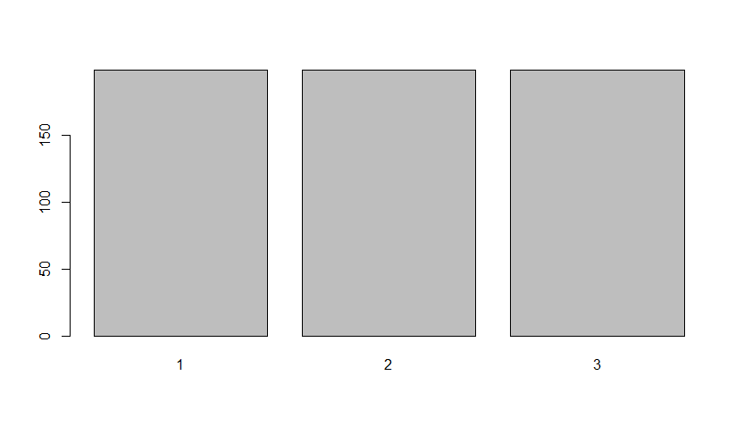

```
xxxxxxxxxx
```

```
In response to the class imbalance in our Vehicle Silhouettes dataset,
```

```
we initially attempted oversampling, which proved ineffective.
```

```
Consequently, we implemented undersampling, successfully addressing the
```

```
issue by reducing the size of the majority class. This approach enhanced
```

```
model performance and became our preferred method for tackling class
```

```
imbalance in our vehicle silhouette classification task.
```

In response to the class imbalance in our Vehicle Silhouettes dataset, we initially attempted oversampling, which proved ineffective. Consequently, we implemented undersampling, successfully addressing the issue by reducing the size of the majority class. This approach enhanced model performance and became our preferred method for tackling class imbalance in our vehicle silhouette classification task.

```
xxxxxxxxxx
```

```
<p></p>
```

```
xxxxxxxxxx
```

```
###Encoding categorical data
```

```
dataset$class = factor(dataset$class,levels = c("bus","car", "van"), labels = c(1, 2, 3))
```

```
xxxxxxxxxx
```

```
##Dealing with  missing value
```

```
dataset$compactness[is.na(dataset$compactness)]<- (median(dataset$compactness, na.rm =TRUE))
```

```
dataset$circularity[is.na(dataset$circularity)]<- (median(dataset$circularity, na.rm =TRUE))
```

```
dataset$distance_circularity[is.na(dataset$distance_circularity)]<- (median(dataset$distance_circularity, na.rm =TRUE))
```

```
dataset$radius_ratio[is.na(dataset$radius_ratio)]<- (median(dataset$radius_ratio, na.rm =TRUE))
```

```
dataset$pr.axis_aspect_ratio[is.na(dataset$pr.axis_aspect_ratio)]<- (median(dataset$pr.axis_aspect_ratio, na.rm =TRUE))
```

```
dataset$max.length_aspect_ratio[is.na(dataset$max.length_aspect_ratio)]<- (median(dataset$max.length_aspect_ratio, na.rm =TRUE))
```

```
dataset$scatter_ratio[is.na(dataset$scatter_ratio)]<- (median(dataset$scatter_ratio, na.rm =TRUE))
```

```
dataset$elongatedness[is.na(dataset$elongatedness)]<- (median(dataset$elongatedness, na.rm =TRUE))
```

```
dataset$pr.axis_rectangularity[is.na(dataset$pr.axis_rectangularity)]<- (median(dataset$pr.axis_rectangularity, na.rm =TRUE))
```

```
dataset$max.length_rectangularity[is.na(dataset$max.length_rectangularity)]<- (median(dataset$max.length_rectangularity, na.rm =TRUE))
```

```
dataset$scaled_variance[is.na(dataset$scaled_variance)]<- (median(dataset$scaled_variance, na.rm =TRUE))
```

```
dataset$scaled_variance.1[is.na(dataset$scaled_variance.1)]<- (median(dataset$scaled_variance.1, na.rm =TRUE))
```

```
dataset$scaled_radius_of_gyration[is.na(dataset$scaled_radius_of_gyration)]<- (median(dataset$scaled_radius_of_gyration, na.rm =TRUE))
```

```
dataset$scaled_radius_of_gyration.1[is.na(dataset$scaled_radius_of_gyration.1)]<- (median(dataset$scaled_radius_of_gyration.1, na.rm =TRUE))
```

```
dataset$skewness_about[is.na(dataset$skewness_about)]<- (median(dataset$skewness_about, na.rm =TRUE))
```

```
dataset$skewness_about.1[is.na(dataset$skewness_about.1)]<- (median(dataset$skewness_about.1, na.rm =TRUE))
```

```
dataset$skewness_about.2[is.na(dataset$skewness_about.2)]<- (median(dataset$skewness_about.2, na.rm =TRUE))
```

```
dataset$hollows_ratio[is.na(dataset$hollows_ratio)]<- (median(dataset$hollows_ratio, na.rm =TRUE))
```

```
xxxxxxxxxx
```

```
 <p>We have removed the missing values and set it as  median to ensures that we maintain the overall central tendency of the dataset, minimizing the potential distortion of the size-related information. </p>
```

We have removed the missing values and set it as median to ensures that we maintain the overall central tendency of the dataset, minimizing the potential distortion of the size-related information.

```
xxxxxxxxxx
```

```
## outliers analysis
```

```
##radius_ratio founded outliers 3
```

```
quartiles <- quantile(dataset$radius_ratio, probs=c(.25, .75), na.rm = FALSE)
```

```
IQR <- IQR(dataset$radius_ratio)
```

```
Lower <- quartiles[1] - 1.5*IQR
```

```
Upper <- quartiles[2] + 1.5*IQR
```

```
data_no_outlier <- subset(dataset, dataset$radius_ratio > Lower & dataset$radius_ratio < Upper)
```

```
dim(data_no_outlier)
```

```
##pr.axis_aspect_ratio outliers 8
```

```
quartiles <- quantile(dataset$pr.axis_aspect_ratio, probs=c(.25, .75), na.rm = FALSE)
```

```
IQR <- IQR(dataset$pr.axis_aspect_ratio)
```

```
Lower <- quartiles[1] - 1.5*IQR
```

```
Upper <- quartiles[2] + 1.5*IQR
```

```
data_no_outlier <- subset(dataset, dataset$pr.axis_aspect_ratio > Lower & dataset$pr.axis_aspect_ratio < Upper)
```

```
dim(data_no_outlier)
```

[output not shown]

```
quartiles <- quantile(dataset$max.length_aspect_ratio, probs=c(.25, .75), na.rm = FALSE)
```

```
IQR <- IQR(dataset$max.length_aspect_ratio)
```

```
Lower <- quartiles[1] - 1.5*IQR
```

```
Upper <- quartiles[2] + 1.5*IQR
```

```
data_no_outlier <- subset(dataset, dataset$max.length_aspect_ratio > Lower & dataset$max.length_aspect_ratio < Upper)
```

```
dim(data_no_outlier)
```

```
##scaled_variance outliers is 1
```

```
quartiles <- quantile(dataset$scaled_variance, probs=c(.25, .75), na.rm = FALSE)
```

```
IQR <- IQR(dataset$scaled_variance)
```

```
Lower <- quartiles[1] - 1.5*IQR
```

```
Upper <- quartiles[2] + 1.5*IQR
```

```
data_no_outlier <- subset(dataset, dataset$scaled_variance > Lower & dataset$scaled_variance < Upper)
```

```
dim(data_no_outlier)
```

```
##scaled_variance.1 outliers is 2
```

```
quartiles <- quantile(dataset$scaled_variance.1, probs=c(.25, .75), na.rm = FALSE)
```

```
IQR <- IQR(dataset$scaled_variance.1)
```

```
Lower <- quartiles[1] - 1.5*IQR
```

```
Upper <- quartiles[2] + 1.5*IQR
```

```
data_no_outlier <- subset(dataset, dataset$scaled_variance.1 > Lower & dataset$scaled_variance.1 < Upper)
```

```
dim(data_no_outlier)
```

```
##scaled_radius_of_gyration.1 is outliers is 10
```

```
quartiles <- quantile(dataset$scaled_radius_of_gyration.1, probs=c(.25, .75), na.rm = FALSE)
```

```
IQR <- IQR(dataset$scaled_variance.1)
```

```
Lower <- quartiles[1] - 1.5*IQR
```

```
Upper <- quartiles[2] + 1.5*IQR
```

```
data_no_outlier <- subset(dataset, dataset$scaled_radius_of_gyration.1 > Lower & dataset$scaled_radius_of_gyration.1 < Upper)
```

```
dim(data_no_outlier)
```

```
##skewness_about is outliers is 3
```

```
quartiles <- quantile(dataset$skewness_about, probs=c(.25, .75), na.rm = FALSE)
```

```
IQR <- IQR(dataset$skewness_about)
```

```
Lower <- quartiles[1] - 1.5*IQR
```

```
Upper <- quartiles[2] + 1.5*IQR
```

```
data_no_outlier <- subset(dataset, dataset$skewness_about > Lower & dataset$skewness_about < Upper)
```

```
dim(data_no_outlier
```

```
##skewness_about.1 is outliers is 3
```

```
quartiles <- quantile(dataset$skewness_about.1, probs=c(.25, .75), na.rm = FALSE)
```

```
IQR <- IQR(dataset$skewness_about.1)
```

```
Lower <- quartiles[1] - 1.5*IQR
```

```
Upper <- quartiles[2] + 1.5*IQR
```

```
data_no_outlier <- subset(dataset, dataset$skewness_about.1 > Lower & dataset$skewness_about.1 < Upper)
```

```
dim(data_no_outlier)
```

1. 838

2. 19

1. 833

2. 19

1. 845

2. 19

1. 844

2. 19

1. 846

2. 19

1. 834

2. 19

1. 844

2. 19

```
xxxxxxxxxx
```

```
##feature selection
```

```
cor(dataset[, unlist(lapply(dataset, is.numeric))])
```

```
dataset<- subset(dataset, select = -pr.axis_rectangularity)
```

```
dataset<- subset(dataset, select = -compactness)
```

```
xxxxxxxxxx
```

```
<p>We found that pr.axis_rectangularity in our dataset that is strongly correlated with multiple other columns, it indicates multicollinearity, where features are closely related, making model building challenging. In such cases, feature selection is vital, involving the careful choice of relevant and independent features while reducing redundancy.</p>
```

We found that pr.axis_rectangularity in our dataset that is strongly correlated with multiple other columns, it indicates multicollinearity, where features are closely related, making model building challenging. In such cases, feature selection is vital, involving the careful choice of relevant and independent features while reducing redundancy.

```
xxxxxxxxxx
```

```
##normalization
```

```
normalize <- function(x) {return((x-min(x))/ (max(x)-min(x)))}
```

```
dataset$scaled_variance.1 <-normalize(dataset$scaled_variance.1)
```

```
xxxxxxxxxx
```

```
<p>Using normalization on Scaled_variance.1 means adjusting its values to a similar scale as other columns in the dataset to prevent one column from dominating the analysis or modeling process.However we did not normalize the rest of our columns since the range provided is already considered a small one.</p>
```

Using normalization on Scaled_variance.1 means adjusting its values to a similar scale as other columns in the dataset to prevent one column from dominating the analysis or modeling process.However we did not normalize the rest of our columns since the range provided is already considered a small one.

```
xxxxxxxxxx
```

```
<h5>Discretization</h5>
```

```
<p>Since our dataset is mainly size related variables its best to retain them as continuous variable without discretization. </p>
```

##### Discretization

Since our dataset is mainly size related variables its best to retain them as continuous variable without discretization.

```
xxxxxxxxxx
```

```
During the **pre-processing** phase, our initial step involved encoding
```

```
categorical data. We proceeded by managing missing values, replacing
```

```
them with the median to preserve the dataset's central tendency and
```

```
avoid altering the size-related information significantly. Later, while
```

```
addressing outliers, we discovered a strong correlation with the
```

```
'pr.axis_rectangularity'  column, alongside multiple
```

```
others, signaling multicollinearity. This situation implies that
```

```
features are highly interrelated, posing a challenge in model
```

```
construction. Consequently, we emphasized feature selection, focusing on
```

```
relevant and independent attributes to diminish redundancy.
```

```
Subsequently, normalization was applied to 'Scaled_variance.1' to align
```

```
its scale with other columns, preventing dominance in the analysis or
```

```
modeling process. Nonetheless, normalization wasn't extended to the
```

```
remaining columns, as their provided range was already considered
```

```
relatively small. Considering our dataset primarily comprises
```

```
size-related variables, we opted to retain them as continuous variables
```

```
without discretization.We also applied undersampling to balance our classlabel. After these preprocessing steps, the data was
```

```
cleansed, preparing it for the application of data mining techniques.
```

During the **pre-processing** phase, our initial step involved encoding categorical data. We proceeded by managing missing values, replacing them with the median to preserve the dataset's central tendency and avoid altering the size-related information significantly. Later, while addressing outliers, we discovered a strong correlation with the 'pr.axis_rectangularity' column, alongside multiple others, signaling multicollinearity. This situation implies that features are highly interrelated, posing a challenge in model construction. Consequently, we emphasized feature selection, focusing on relevant and independent attributes to diminish redundancy. Subsequently, normalization was applied to 'Scaled_variance.1' to align its scale with other columns, preventing dominance in the analysis or modeling process. Nonetheless, normalization wasn't extended to the remaining columns, as their provided range was already considered relatively small. Considering our dataset primarily comprises size-related variables, we opted to retain them as continuous variables without discretization.We also applied undersampling to balance our classlabel. After these preprocessing steps, the data was cleansed, preparing it for the application of data mining techniques.

```
xxxxxxxxxx
```

```
<h3>After pre-processing</h3>
```

### After pre-processing

```
xxxxxxxxxx
```

```
##Data before preprocessing
```

```
head(databeforereprossess)
```

| compactness | circularity | distance_circularity | radius_ratio | pr.axis_aspect_ratio | max.length_aspect_ratio | scatter_ratio | elongatedness | pr.axis_rectangularity | max.length_rectangularity | scaled_variance | scaled_variance.1 | scaled_radius_of_gyration | scaled_radius_of_gyration.1 | skewness_about | skewness_about.1 | skewness_about.2 | hollows_ratio | class |
| --- | --- | --- | --- | --- | --- | --- | --- | --- | --- | --- | --- | --- | --- | --- | --- | --- | --- | --- |
| 95 | 48 | 83 | 178 | 72 | 10 | 162 | 42 | 20 | 159 | 176 | 379 | 184 | 70 | 6 | 16 | 187 | 197 | van |
| 91 | 41 | 84 | 141 | 57 | 9 | 149 | 45 | 19 | 143 | 170 | 330 | 158 | 72 | 9 | 14 | 189 | 199 | van |
| 104 | 50 | 106 | 209 | 66 | 10 | 207 | 32 | 23 | 158 | 223 | 635 | 220 | 73 | 14 | 9 | 188 | 196 | car |
| 93 | 41 | 82 | 159 | 63 | 9 | 144 | 46 | 19 | 143 | 160 | 309 | 127 | 63 | 6 | 10 | 199 | 207 | van |
| 85 | 44 | 70 | 205 | 103 | 52 | 149 | 45 | 19 | 144 | 241 | 325 | 188 | 127 | 9 | 11 | 180 | 183 | bus |
| 107 | NA | 106 | 172 | 50 | 6 | 255 | 26 | 28 | 169 | 280 | 957 | 264 | 85 | 5 | 9 | 181 | 183 | bus |

```
xxxxxxxxxx
```

```
##Lets take a look at our dataset after preprocessing
```

```
head(dataset)
```

[output not shown]

```
xxxxxxxxxx
```

```
<p>In conclusion, our initial examination of the dataset involved several key steps. We began by identifying the attributes contained within the dataset, providing us with an understanding of the types of data we are working with. We gathered general information about the dataset and added some visualizations  to provide a clearer and more intuitive understanding of the data.Then lastly we began the preprocessing stage, a critical phase , where we  made only the necessary adjustments required to prepare the dataset for more advanced analyses. This ensured that our data was clean and reliable.</p>
```

In conclusion, our initial examination of the dataset involved several key steps. We began by identifying the attributes contained within the dataset, providing us with an understanding of the types of data we are working with. We gathered general information about the dataset and added some visualizations to provide a clearer and more intuitive understanding of the data.Then lastly we began the preprocessing stage, a critical phase , where we made only the necessary adjustments required to prepare the dataset for more advanced analyses. This ensured that our data was clean and reliable.

```
xxxxxxxxxx
```

```
<h1>C.Data mining techniques</h1>
```

# C.Data mining techniques

```
xxxxxxxxxx
```

```
<h2>1.Classification</h2>
```

## 1.Classification

```
xxxxxxxxxx
```

```
Our focus on the Vehicle Silhouettes dataset centers on accurately classifying vehicle silhouettes into three categories: car, van, or bus. Extracted silhouette-based features guide this classification, and our goal is to leverage metrics like information gain, Gini index, and gain ratio to discern patterns for precise categorization. The dataset comprises various features, each playing a role in the classification process. The ultimate aim is to efficiently utilize these features to distinguish and categorize the diverse vehicle silhouettes in our dataset.
```

Our focus on the Vehicle Silhouettes dataset centers on accurately classifying vehicle silhouettes into three categories: car, van, or bus. Extracted silhouette-based features guide this classification, and our goal is to leverage metrics like information gain, Gini index, and gain ratio to discern patterns for precise categorization. The dataset comprises various features, each playing a role in the classification process. The ultimate aim is to efficiently utilize these features to distinguish and categorize the diverse vehicle silhouettes in our dataset.

```
xxxxxxxxxx
```

```
<h3>1.1:Information Gain</h3>
```

### 1.1:Information Gain

```
xxxxxxxxxx
```

```
Information gain is a key concept in the field of machine learning and
```

```
decision trees. It is a metric used to measure the effectiveness of an
```

```
attribute in classifying data. In the context of decision trees,
```

```
information gain helps determine the most valuable attribute for
```

```
splitting data by quantifying the amount of uncertainty reduced after
```

```
splitting the data based on a particular attribute. In essence, it aids
```

```
in identifying the attributes that contribute the most to the
```

```
classification process. In this R code, we'll explore the calculation
```

```
and application of information gain.
```

Information gain is a key concept in the field of machine learning and decision trees. It is a metric used to measure the effectiveness of an attribute in classifying data. In the context of decision trees, information gain helps determine the most valuable attribute for splitting data by quantifying the amount of uncertainty reduced after splitting the data based on a particular attribute. In essence, it aids in identifying the attributes that contribute the most to the classification process. In this R code, we'll explore the calculation and application of information gain.

```
xxxxxxxxxx
```

```
<h5>Some information to Know</h5>
```

##### Some information to Know

```
xxxxxxxxxx
```

```
We aim to conduct three different data splits using the same formula to
```

```
observe the variations in outcomes. After exploring numerous attribute
```

```
combinations to construct the formula based on information gain, we
```

```
settled on utilizing (scaled_variance.1, scatter_ratio, elongatedness,
```

```
scaled_variance, radius_ratio) as our selected attributes. This decision
```

```
was made after testing multiple attribute combinations and finding that
```

```
these particular attributes consistently led to clear and non-confusing
```

```
tree representations. Employing the same formula across the three splits
```

```
will enable us to explicitly observe the distinctions arising from the
```

```
different datasets and how these variations affect the decision tree
```

```
structures.
```

We aim to conduct three different data splits using the same formula to observe the variations in outcomes. After exploring numerous attribute combinations to construct the formula based on information gain, we settled on utilizing (scaled_variance.1, scatter_ratio, elongatedness, scaled_variance, radius_ratio) as our selected attributes. This decision was made after testing multiple attribute combinations and finding that these particular attributes consistently led to clear and non-confusing tree representations. Employing the same formula across the three splits will enable us to explicitly observe the distinctions arising from the different datasets and how these variations affect the decision tree structures.

```
xxxxxxxxxx
```

```
<h5>Steps we will apply here:</h5>
```

##### Steps we will apply here:

```
xxxxxxxxxx
```

```
In this selection process, we initiated by dividing the dataset into
```

```
training and testing subsets across three varied partitions. A uniform
```

```
formula was then employed consistently across all three partitions.
```

```
Subsequently, decision trees were constructed using the training set,
```

```
and predictions were evaluated, followed by the visualization of the
```

```
tree structure. The model was utilized to predict class labels for the
```

```
test data, and a thorough evaluation, including the extraction of
```

```
measures such as accuracy, was conducted to assess the effectiveness of
```

```
the partitioning strategy.
```

In this selection process, we initiated by dividing the dataset into training and testing subsets across three varied partitions. A uniform formula was then employed consistently across all three partitions. Subsequently, decision trees were constructed using the training set, and predictions were evaluated, followed by the visualization of the tree structure. The model was utilized to predict class labels for the test data, and a thorough evaluation, including the extraction of measures such as accuracy, was conducted to assess the effectiveness of the partitioning strategy.

```
xxxxxxxxxx
```

```
<h4>1.1.A:split on 70% training and 30%testing</h4>
```

#### 1.1.A:split on 70% training and 30%testing

```
xxxxxxxxxx
```

```
<h6>First we split dataset into training and testing subnets</h6>
```

###### First we split dataset into training and testing subnets

```
xxxxxxxxxx
```

```
##Needed library
```

```
library(party)
```

```
library(e1071)
```

```
library(caret)
```

```
xxxxxxxxxx
```

```
# 1. Split the dataset into training and testing subsets
```

```
set.seed(123)  # Set a seed for reproducibility
```

```
ind <- sample(2, nrow(dataset), replace = TRUE, prob = c(0.7, 0.3))
```

```
train.data <- dataset[ind == 1, ]
```

```
test.data <- dataset[ind == 2, ]
```

```
xxxxxxxxxx
```

```
# 2. Define the formula for the model
```

```
myFormula <- Class ~ scaled_variance.1  + scatter_ratio + elongatedness + scaled_variance + radius_ratio
```

```
xxxxxxxxxx
```

```
# 3. Build the decision tree using the training set
```

```
dataset.ctree <- ctree(myFormula, data = train.data)
```

```
xxxxxxxxxx
```

```
# 4. Check the prediction on the training set
```

```
trainPred <- predict(dataset.ctree)
```

```
table(trainPred, train.data$Class)
```

```
xxxxxxxxxx
```

```
<pre>trainPred   1   2   3
```

```
        1  82  16  25
```

```
        2  62 101   4
```

```
        3   0  23 109</pre>
```

```
trainPred   1   2   3
        1  82  16  25
        2  62 101   4
        3   0  23 109
```

```
xxxxxxxxxx
```

```
This confusion matrix provides valuable insights into the strengths and weaknesses of our model's predictions across different classes.
```

This confusion matrix provides valuable insights into the strengths and weaknesses of our model's predictions across different classes.

```
xxxxxxxxxx
```

```
# 5.Print and plot the tree:
```

```
print(dataset.ctree)
```

```
plot(dataset.ctree, type="simple")
```

```
xxxxxxxxxx
```

```
<pre> Conditional inference tree with 5 terminal nodes
```

```
Response:  Class
```

```
Inputs:  scaled_variance.1, scatter_ratio, elongatedness, scaled_variance, radius_ratio
```

```
Number of observations:  422
```

```
1) elongatedness <= 41; criterion = 1, statistic = 128.537
```

```
  2)*  weights = 156
```

```
1) elongatedness > 41
```

```
  3) elongatedness <= 46; criterion = 1, statistic = 35.975
```

```
    4) scatter_ratio <= 154; criterion = 1, statistic = 33.346
```

```
      5)*  weights = 123
```

```
    4) scatter_ratio > 154
```

```
      6) elongatedness <= 42; criterion = 0.999, statistic = 17.63
```

```
        7)*  weights = 11
```

```
      6) elongatedness > 42
```

```
        8)*  weights = 36
```

```
  3) elongatedness > 46
```

```
    9)*  weights = 96  </pre>
```

```
 Conditional inference tree with 5 terminal nodes

Response:  Class
Inputs:  scaled_variance.1, scatter_ratio, elongatedness, scaled_variance, radius_ratio
Number of observations:  422

1) elongatedness <= 41; criterion = 1, statistic = 128.537
  2)*  weights = 156
1) elongatedness > 41
  3) elongatedness <= 46; criterion = 1, statistic = 35.975
    4) scatter_ratio <= 154; criterion = 1, statistic = 33.346
      5)*  weights = 123
    4) scatter_ratio > 154
      6) elongatedness <= 42; criterion = 0.999, statistic = 17.63
        7)*  weights = 11
      6) elongatedness > 42
        8)*  weights = 36
  3) elongatedness > 46
    9)*  weights = 96
```

```
xxxxxxxxxx
```

```
![tree73.png](attachment:tree73.png)
```

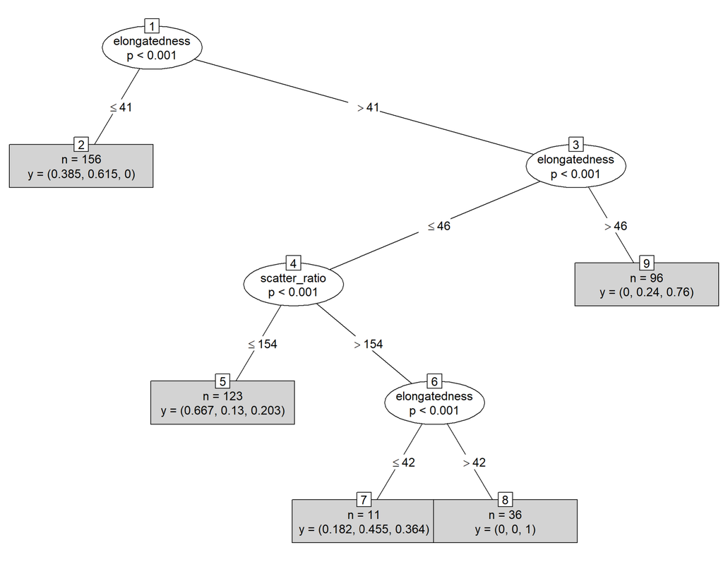

```
xxxxxxxxxx
```

```
This decision tree is constructed for the purpose of class prediction, utilizing features such as scaled_variance.1, scatter_ratio, elongatedness, scaled_variance, and radius_ratio. The weights assigned to the terminal nodes signify the count of observations categorized into each class. These terminal nodes serve as the ultimate decision points, representing the final predictions for distinct subgroups within the dataset.
```

This decision tree is constructed for the purpose of class prediction, utilizing features such as scaled_variance.1, scatter_ratio, elongatedness, scaled_variance, and radius_ratio. The weights assigned to the terminal nodes signify the count of observations categorized into each class. These terminal nodes serve as the ultimate decision points, representing the final predictions for distinct subgroups within the dataset.

```
xxxxxxxxxx
```

```
# 6. Use the model to predict the class labels of the test data
```

```
testPred <- predict(dataset.ctree, newdata = test.data)
```

```
result <- table(testPred, test.data$Class)
```

```
xxxxxxxxxx
```

```
# 7. Evaluate the model
```

```
library(e1071)
```

```
library(caret)
```

```
co_result <- confusionMatrix(result)
```

```
print(co_result)
```

```
# Extracting sensitivity and specificity from the table in co_result
```

```
table_matrix <- co_result$table
```

```
# Extracting true positives (TP), true negatives (TN), false positives (FP), and false negatives (FN)
```

```
TP <- table_matrix[2, 2]  # True Positive
```

```
TN <- sum(diag(table_matrix)) - sum(table_matrix[2, ]) - sum(table_matrix[, 2]) + TP  # True Negative
```

```
FP <- sum(table_matrix[, 2]) - TP  # False Positive
```

```
FN <- sum(table_matrix[2, ]) - TP  # False Negative
```

```
# Calculate sensitivity and specificity
```

```
sensitivity <- TP / (TP + FN)
```

```
specificity <- TN / (TN + FP)
```

```
# Print the sensitivity and specificity
```

```
print(sensitivity)
```

```
print(specificity)
```

```
accuracy <- co_result$overall["Accuracy"]
```

```
accuracy
```

```
xxxxxxxxxx
```

```
<pre>Confusion Matrix and Statistics
```

```
testPred  1  2  3
```

```
       1 31  2 14
```

```
       2 23 48  2
```

```
       3  1  9 45
```

```
Overall Statistics
```

```
               Accuracy : 0.7086
```

```
                 95% CI : (0.6352, 0.7747)
```

```
    No Information Rate : 0.3486
```

```
    P-Value [Acc > NIR] : < 2.2e-16
```

```
                  Kappa : 0.562
```

```
 Mcnemar's Test P-Value : 2.702e-07
```

```
Statistics by Class:
```

```
                     Class: 1 Class: 2 Class: 3
```

```
Sensitivity            0.5636   0.8136   0.7377
```

```
Specificity            0.8667   0.7845   0.9123
```

```
Pos Pred Value         0.6596   0.6575   0.8182
```

```
Neg Pred Value         0.8125   0.8922   0.8667
```

```
Prevalence             0.3143   0.3371   0.3486
```

```
Detection Rate         0.1771   0.2743   0.2571
```

```
Detection Prevalence   0.2686   0.4171   0.3143
```

```
Balanced Accuracy      0.7152   0.7990   0.8250
```

```
        </pre>
```

```
Confusion Matrix and Statistics


testPred  1  2  3
       1 31  2 14
       2 23 48  2
       3  1  9 45

Overall Statistics

               Accuracy : 0.7086
                 95% CI : (0.6352, 0.7747)
    No Information Rate : 0.3486
    P-Value [Acc > NIR] : < 2.2e-16

                  Kappa : 0.562

 Mcnemar's Test P-Value : 2.702e-07

Statistics by Class:

                     Class: 1 Class: 2 Class: 3
Sensitivity            0.5636   0.8136   0.7377
Specificity            0.8667   0.7845   0.9123
Pos Pred Value         0.6596   0.6575   0.8182
Neg Pred Value         0.8125   0.8922   0.8667
Prevalence             0.3143   0.3371   0.3486
Detection Rate         0.1771   0.2743   0.2571
Detection Prevalence   0.2686   0.4171   0.3143
Balanced Accuracy      0.7152   0.7990   0.8250
```

```
xxxxxxxxxx
```

```
 <pre>print(sensitivity)
```

```
[1] 0.6575342
```

```
print(specificity)
```

```
[1] 0.7843137</pre>
```

```
print(sensitivity)
[1] 0.6575342
print(specificity)
[1] 0.7843137
```

```
xxxxxxxxxx
```

```
 Accuracy
```

```
0.7085714
```

Accuracy 0.7085714

```
xxxxxxxxxx
```

[output not shown]

```
xxxxxxxxxx
```

```
<h4>1.1.B:split on 80% training and 20%testing</h4>
```

#### 1.1.B:split on 80% training and 20%testing

```
xxxxxxxxxx
```

```
# 1. Split the dataset into training and testing subsets
```

```
set.seed(123)  # Set a seed for reproducibility
```

```
ind <- sample(2, nrow(dataset), replace = TRUE, prob = c(0.8, 0.2))
```

```
train.data <- dataset[ind == 1, ]
```

```
test.data <- dataset[ind == 2, ]
```

```
xxxxxxxxxx
```

```
# 2. Define the formula for the model
```

```
myFormula <- Class ~ scaled_variance + skewness_about.2 + scatter_ratio + elongatedness
```

```
xxxxxxxxxx
```

```
# 3. Build the decision tree using the training set
```

```
dataset.ctree <- ctree(myFormula, data = train.data)
```

```
xxxxxxxxxx
```

```
# 4. Check the prediction on the training set
```

```
trainPred <- predict(dataset.ctree)
```

```
table(trainPred, train.data$Class)
```

```
xxxxxxxxxx
```

```
<pre>trainPred   1   2   3
```

```
        1  79  13  11
```

```
        2  65 115   0
```

```
        3  18  34 142</pre>
```

```
trainPred   1   2   3
        1  79  13  11
        2  65 115   0
        3  18  34 142
```

```
xxxxxxxxxx
```

```
This confusion matrix provides valuable insights into the strengths and weaknesses of our model's predictions across different classes.
```

This confusion matrix provides valuable insights into the strengths and weaknesses of our model's predictions across different classes.

```
xxxxxxxxxx
```

```
# 5.Print and plot the tree:
```

```
print(dataset.ctree)
```

```
plot(dataset.ctree, type="simple")
```

```
xxxxxxxxxx
```

```
<pre>Conditional inference tree with 6 terminal nodes
```

```
Response:  Class
```

[output not shown]

```
Number of observations:  477
```

```
1) elongatedness <= 41; criterion = 1, statistic = 156.166
```

```
  2)*  weights = 180
```

```
1) elongatedness > 41
```

```
  3) elongatedness <= 46; criterion = 1, statistic = 40.256
```

```
    4) scatter_ratio <= 154; criterion = 1, statistic = 32.091
```

```
      5) scatter_ratio <= 147; criterion = 0.99, statistic = 12.414
```

```
        6)*  weights = 38
```

```
      5) scatter_ratio > 147
```

```
        7)*  weights = 103
```

```
    4) scatter_ratio > 154
```

```
      8) elongatedness <= 42; criterion = 0.991, statistic = 12.584
```

```
        9)*  weights = 10
```

```
      8) elongatedness > 42
```

```
        10)*  weights = 41
```

```
  3) elongatedness > 46
```

```
    11)*  weights = 105  </pre>
```

[output not shown]

```
xxxxxxxxxx
```

```
![tree82.png](attachment:tree82.png)
```

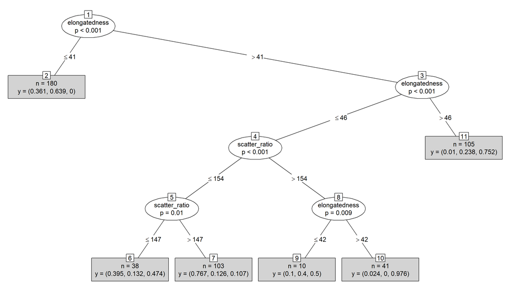

```
xxxxxxxxxx
```

[output not shown]

This conditional inference tree is designed to predict the class based on the input features: scaled_variance.1, scatter_ratio, elongatedness, scaled_variance, and radius_ratio. The tree has 6 terminal nodes, each representing a subgroup of the data with specific characteristics.

```
xxxxxxxxxx
```

```
# 6. Use the model to predict the class labels of the test data
```

```
testPred <- predict(dataset.ctree, newdata = test.data)
```

```
result <- table(testPred, test.data$Class)
```

```
xxxxxxxxxx
```

[output not shown]

[output not shown]

[output not shown]

[output not shown]

[output not shown]

[output not shown]

[output not shown]

[output not shown]

[output not shown]

[output not shown]

[output not shown]

[output not shown]

[output not shown]

[output not shown]

[output not shown]

[output not shown]

[output not shown]

[output not shown]

[output not shown]

[output not shown]

[output not shown]

[output not shown]

[output not shown]

[output not shown]

[output not shown]

[output not shown]

[output not shown]

[output not shown]

[output not shown]

[output not shown]

[output not shown]

[output not shown]

[output not shown]

[output not shown]

[output not shown]

[output not shown]

[output not shown]

[output not shown]

```
xxxxxxxxxx
```

```
# 7. Evaluate the model
```

```
co_result <- confusionMatrix(result)
```

```
print(co_result)
```

```
# Extracting sensitivity and specificity from the table in co_result
```

```
table_matrix <- co_result$table
```

```
# Extracting true positives (TP), true negatives (TN), false positives (FP), and false negatives (FN)
```

```
TP <- table_matrix[2, 2]  # True Positive
```

```
TN <- sum(diag(table_matrix)) - sum(table_matrix[2, ]) - sum(table_matrix[, 2]) + TP  # True Negative
```

```
FP <- sum(table_matrix[, 2]) - TP  # False Positive
```

```
FN <- sum(table_matrix[2, ]) - TP  # False Negative
```

```
# Calculate sensitivity and specificity
```

```
sensitivity <- TP / (TP + FN)
```

```
specificity <- TN / (TN + FP)
```

```
# Print the sensitivity and specificity
```

```
print(sensitivity)
```

```
print(specificity)
```

```
accuracy <- co_result$overall["Accuracy"]
```

```
accuracy
```

```
xxxxxxxxxx
```

```
<pre>   Confusion Matrix and Statistics
```

```
testPred  1  2  3
```

```
       1 17  3  9
```

```
       2 15 30  0
```

```
       3  5  4 37
```

```
Overall Statistics
```

```
               Accuracy :
```

```
                 95% CI :
```

```
    No Information Rate :
```

```
    P-Value [Acc > NIR] :
```

```
                  Kappa :
```

```
 Mcnemar's Test P-Value :
```

```
 0.7
```

```
 (0.6096, 0.7802)
```

```
 0.3833
```

```
 2.125e-12
```

```
 0.5475
```

```
 0.004338
```

```
Statistics by Class:
```

```
                     Class: 1 Class: 2
```

```
Sensitivity            0.4595   0.8108
```

```
Specificity            0.8554   0.8193
```

```
Pos Pred Value         0.5862   0.6667
```

```
Neg Pred Value         0.7802   0.9067
```

```
Prevalence             0.3083   0.3083
```

```
Detection Rate         0.1417   0.2500
```

```
Detection Prevalence   0.2417   0.3750
```

```
Balanced Accuracy      0.6574   0.8150
```

```
                     Class: 3
```

```
Sensitivity            0.8043
```

```
Specificity            0.8784
```

```
Pos Pred Value         0.8043
```

```
Neg Pred Value         0.8784
```

```
Prevalence             0.3833
```

```
Detection Rate         0.3083
```

```
Detection Prevalence   0.3833
```

```
Balanced Accuracy      0.8414
```

```
        </pre>
```

```
   Confusion Matrix and Statistics


testPred  1  2  3
       1 17  3  9
       2 15 30  0
       3  5  4 37

Overall Statistics

               Accuracy :
                 95% CI :
    No Information Rate :
    P-Value [Acc > NIR] :

                  Kappa :

 Mcnemar's Test P-Value :

 0.7
 (0.6096, 0.7802)
 0.3833
 2.125e-12

 0.5475

 0.004338

Statistics by Class:

                     Class: 1 Class: 2
Sensitivity            0.4595   0.8108
Specificity            0.8554   0.8193
Pos Pred Value         0.5862   0.6667
Neg Pred Value         0.7802   0.9067
Prevalence             0.3083   0.3083
Detection Rate         0.1417   0.2500
Detection Prevalence   0.2417   0.3750
Balanced Accuracy      0.6574   0.8150
                     Class: 3
Sensitivity            0.8043
Specificity            0.8784
Pos Pred Value         0.8043
Neg Pred Value         0.8784
Prevalence             0.3833
Detection Rate         0.3083
Detection Prevalence   0.3833
Balanced Accuracy      0.8414
```

```
xxxxxxxxxx
```

```
<pre>print(sensitivity)
```

```
[1] 0.6666667
```

```
print(specificity)
```

```
[1] 0.8205128</pre>
```

```
print(sensitivity)
[1] 0.6666667
print(specificity)
[1] 0.8205128
```

```
xxxxxxxxxx
```

```
Accuracy
```

```
 0.7
```

Accuracy 0.7

```
xxxxxxxxxx
```

[output not shown]

In this second split, we opted for an 80% training and 20% testing division to ensure robust learning and assess the model's performance on new, unseen data. This partitioning resulted in a model with 6 leaf nodes. Although the accuracy slightly decreased to 0.7 compared to the prior partition, marking only a marginal 0.1 drop, this change wasn't substantial. The sensitivity recorded at 0.6666667 and specificity at 0.8205128 demonstrated the model's proficiency in identifying true positives and negatives. Moreover, the Kappa value of 0.5475 indicated a moderate level of agreement, and the Mcnemar's Test P-Value of 0.004338 suggested variances in error rates or predictions between the models or conditions being compared. The model predictions covered three distinct classes (1, 2, 3), detailed in the confusion matrix, revealing true positives, true negatives, false positives, and false negatives for each class.

```
xxxxxxxxxx
```

```
<h4>1.1.C:split on 60% training and 40%testing</h4>
```